# Landing Distance of Commercial Flights

Sagar Shah

1/22/2020

Motivation: To reduce the risk of landing overrun.

Goal: To study what factors and how they would impact the landing distance of a commercial flight.

Data: Landing data (landing distance and other parameters) from 950 commercial flights.

#loading packages

```r
library(readxl)
library(dplyr)
```

```r
library(ggplot2)
library(broom)
```

# Chapter 1: Data Exploration

#Reading both the files and checking their structure

```r
FAA1 <- as.data.frame(read_excel("FAA1.xls"))
FAA2 <- as.data.frame(read_excel("FAA2.xls"))
```

```r
str(FAA1)
```

```
## 'data.frame':    800 obs. of  8 variables:
##  $ aircraft    : chr  "boeing" "boeing" "boeing" "boeing" ...
##  $ duration    : num  98.5 125.7 112 196.8 90.1 ...
##  $ no_pasg     : num  53 69 61 56 70 55 54 57 61 56 ...
##  $ speed_ground: num  107.9 101.7 71.1 85.8 59.9 ...
##  $ speed_air   : num  109 103 NA NA NA ...
##  $ height      : num  27.4 27.8 18.6 30.7 32.4 ...
##  $ pitch       : num  4.04 4.12 4.43 3.88 4.03 ...
##  $ distance    : num  3370 2988 1145 1664 1050 ...
```

```r
#There are 800 observations and 8 variables in FAA1 dataset.

str(FAA2)
```

```
## 'data.frame':    150 obs. of  7 variables:
##  $ aircraft    : chr  "boeing" "boeing" "boeing" "boeing" ...
##  $ no_pasg     : num  53 69 61 56 70 55 54 57 61 56 ...
##  $ speed_ground: num  107.9 101.7 71.1 85.8 59.9 ...
##  $ speed_air   : num  109 103 NA NA NA ...
##  $ height      : num  27.4 27.8 18.6 30.7 32.4 ...
##  $ pitch       : num  4.04 4.12 4.43 3.88 4.03 ...
##  $ distance    : num  3370 2988 1145 1664 1050 ...
```

```r
#There are 150 observations and 7 variables in FAA2 dataset.
#Key difference between the two is that the variable duration is missing in FAA2 dataset.
```

#Merging Datasets

```r
FAA2$duration <- NA
FAA <- rbind(FAA1, FAA2)
str(FAA)
```

```
## 'data.frame':    950 obs. of  8 variables:
##  $ aircraft    : chr  "boeing" "boeing" "boeing" "boeing" ...
##  $ duration    : num  98.5 125.7 112 196.8 90.1 ...
##  $ no_pasg     : num  53 69 61 56 70 55 54 57 61 56 ...
##  $ speed_ground: num  107.9 101.7 71.1 85.8 59.9 ...
##  $ speed_air   : num  109 103 NA NA NA ...
##  $ height      : num  27.4 27.8 18.6 30.7 32.4 ...
##  $ pitch       : num  4.04 4.12 4.43 3.88 4.03 ...
##  $ distance    : num  3370 2988 1145 1664 1050 ...
```

#Check for duplicates

```r
library(dplyr)
FAA_Nodup <- FAA %>% distinct(aircraft, no_pasg, speed_ground, speed_air,
                       height,  pitch, distance, .keep_all = TRUE)
str(FAA_Nodup)
```

```
## 'data.frame':    850 obs. of  8 variables:
##  $ aircraft    : chr  "boeing" "boeing" "boeing" "boeing" ...
##  $ duration    : num  98.5 125.7 112 196.8 90.1 ...
##  $ no_pasg     : num  53 69 61 56 70 55 54 57 61 56 ...
##  $ speed_ground: num  107.9 101.7 71.1 85.8 59.9 ...
##  $ speed_air   : num  109 103 NA NA NA ...
##  $ height      : num  27.4 27.8 18.6 30.7 32.4 ...
##  $ pitch       : num  4.04 4.12 4.43 3.88 4.03 ...
##  $ distance    : num  3370 2988 1145 1664 1050 ...
```

```r
summary(FAA_Nodup)
```

```
##    aircraft            duration         no_pasg      speed_ground
##  Length:850         Min.   : 14.76   Min.   :29.0   Min.   : 27.74
##  Class :character   1st Qu.:119.49   1st Qu.:55.0   1st Qu.: 65.90
##  Mode  :character   Median :153.95   Median :60.0   Median : 79.64
##                     Mean   :154.01   Mean   :60.1   Mean   : 79.45
##                     3rd Qu.:188.91   3rd Qu.:65.0   3rd Qu.: 92.06
##                     Max.   :305.62   Max.   :87.0   Max.   :141.22
##                     NA's   :50
##    speed_air          height           pitch          distance
##  Min.   : 90.00   Min.   :-3.546   Min.   :2.284   Min.   :  34.08
##  1st Qu.: 96.25   1st Qu.:23.314   1st Qu.:3.642   1st Qu.: 883.79
##  Median :101.15   Median :30.093   Median :4.008   Median :1258.09
##  Mean   :103.80   Mean   :30.144   Mean   :4.009   Mean   :1526.02
##  3rd Qu.:109.40   3rd Qu.:36.993   3rd Qu.:4.377   3rd Qu.:1936.95
##  Max.   :141.72   Max.   :59.946   Max.   :5.927   Max.   :6533.05
##  NA's   :642
```

Key Findings from the initial analysis are listed below:

- Dataset FAA2 does not contain column duration which leads to 150 missing values in the combined dataset.
- Variable speed_air contain 642 NA’s which can mislead the analysis/modelling if taken into consideration.
- Variable height contains negative values which can be treated as abnormal.
- Variable duration contains minimum value of 14.76 which is again abnormal in real life.
- Variable distance contains minimum value of 34.08 which is again abnoraml in real life.
- Datatype of “Aircraft” needs to be changed to factor as it contains only two values.

# Chapter 2: Data Cleaning

#Changing the datatype of variable aircraft to factor FAA_Nodup$aircraft <- as.factor(FAA_Nodup$aircraft)

#Clean Abnormal values

```r
FAA_Cleaned <- FAA_Nodup %>%
  filter(duration > 40 | is.na(duration)) %>%
  filter((speed_ground >= 30 && speed_ground <= 140) | is.na(speed_ground)) %>%
  filter((speed_air >= 30 && speed_air <= 140) | is.na(speed_air)) %>%
  filter(height >= 6 | is.na(height)) %>%
  filter(distance < 6000 | is.na(distance))
```

#counting abnormal values

```r
clean_duration <- sum((FAA_Nodup$duration > 40 | is.na(FAA_Nodup$duration)))
clean_speedair <- sum(((FAA_Nodup$speed_air >= 30 && FAA_Nodup$speed_air <= 140) |                               is.na(FAA_Nodup$speed_air)))
clean_speedground <- sum(((FAA_Nodup$speed_ground >= 30 && FAA_Nodup$speed_ground <=                                140) | is.na(FAA_Nodup$speed_ground)))
clean_height <- sum((FAA_Nodup$height >= 6 | is.na(FAA_Nodup$height)))
clean_distance <- sum((FAA_Nodup$distance < 6000 | is.na(FAA_Nodup$distance)))

clean_values <- matrix(c(clean_duration,clean_speedair,clean_speedground,
                            clean_height,clean_distance),ncol=1,byrow=TRUE)
colnames(clean_values) <- c("Clean Values")
rownames(clean_values) <- c('Duration','Speed_Air','Speed_Ground','Height','Distance')
clean_values_table <- as.table(clean_values)
print(clean_values_table)
```

```
##              Clean Values
## Duration              845
## Speed_Air             850
## Speed_Ground          850
## Height                840
## Distance              848
```

This implies that variables Duration contains 5 abnormal values, Height contains 10 abnormal values and Distance contains 2 abnormal values which have been removed in the cleaned dataset.

#checking the structure of the combined dataset

```r
str(FAA_Cleaned)
```

```
## 'data.frame':    833 obs. of  8 variables:
##  $ aircraft    : chr  "boeing" "boeing" "boeing" "boeing" ...
##  $ duration    : num  98.5 125.7 112 196.8 90.1 ...
##  $ no_pasg     : num  53 69 61 56 70 55 54 57 61 56 ...
##  $ speed_ground: num  107.9 101.7 71.1 85.8 59.9 ...
##  $ speed_air   : num  109 103 NA NA NA ...
##  $ height      : num  27.4 27.8 18.6 30.7 32.4 ...
##  $ pitch       : num  4.04 4.12 4.43 3.88 4.03 ...
##  $ distance    : num  3370 2988 1145 1664 1050 ...
```

```r
summary(FAA_Cleaned)
```

```
##    aircraft            duration         no_pasg       speed_ground
##  Length:833         Min.   : 41.95   Min.   :29.00   Min.   : 27.74
##  Class :character   1st Qu.:119.67   1st Qu.:55.00   1st Qu.: 66.08
##  Mode  :character   Median :154.28   Median :60.00   Median : 79.75
##                     Mean   :154.83   Mean   :60.04   Mean   : 79.42
##                     3rd Qu.:189.75   3rd Qu.:65.00   3rd Qu.: 91.87
##                     Max.   :305.62   Max.   :87.00   Max.   :132.78
##                     NA's   :50
##    speed_air          height           pitch          distance
##  Min.   : 90.00   Min.   : 6.228   Min.   :2.284   Min.   :  41.72
##  1st Qu.: 96.23   1st Qu.:23.530   1st Qu.:3.641   1st Qu.: 893.58
##  Median :101.12   Median :30.159   Median :4.004   Median :1262.15
##  Mean   :103.48   Mean   :30.442   Mean   :4.006   Mean   :1521.71
##  3rd Qu.:109.36   3rd Qu.:36.995   3rd Qu.:4.371   3rd Qu.:1936.01
##  Max.   :132.91   Max.   :59.946   Max.   :5.927   Max.   :5381.96
##  NA's   :630
```

#we convert the ‘aircraft’ variable to integer and code it into 0 and 1 where airbus aircrafts are represented by ‘0’ and boeing aircrafts are represented by ‘1’.

```r
FAA_Cleaned$aircraft <- as.integer(as.factor(FAA_Cleaned$aircraft))
FAA_Cleaned$aircraft <- FAA_Cleaned$aircraft-1
```

#plotting histograms of all variables in the dataset

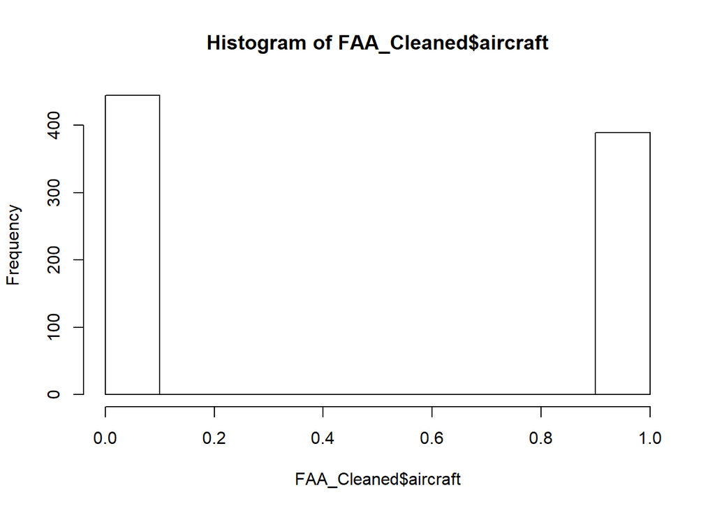

```r
hist(FAA_Cleaned$aircraft)
```

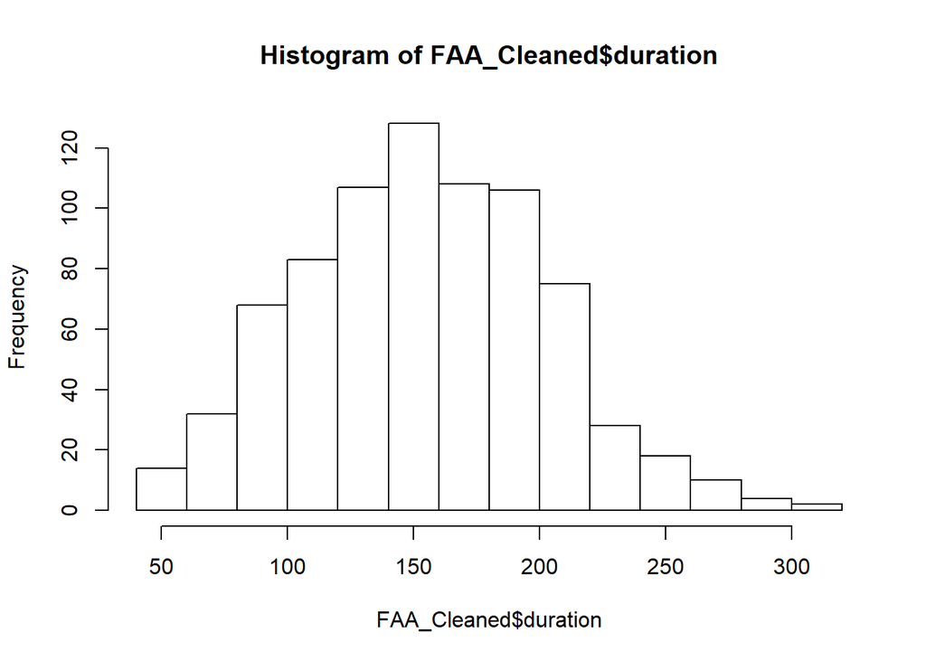

```r
hist(FAA_Cleaned$duration)
```

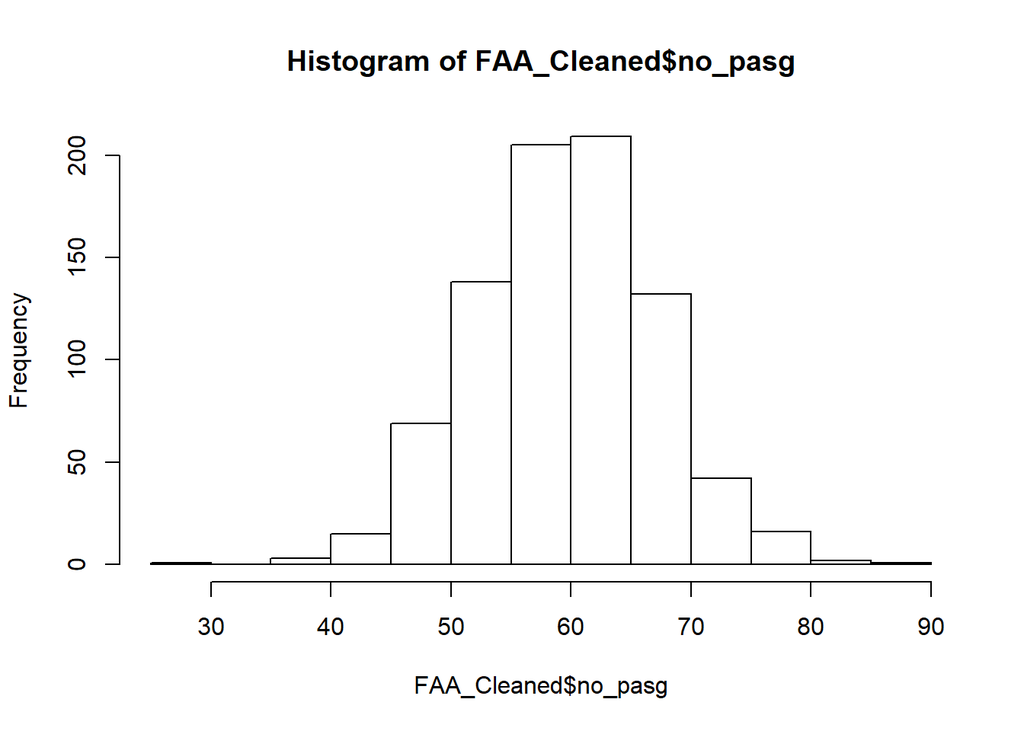

```r
hist(FAA_Cleaned$no_pasg)
```

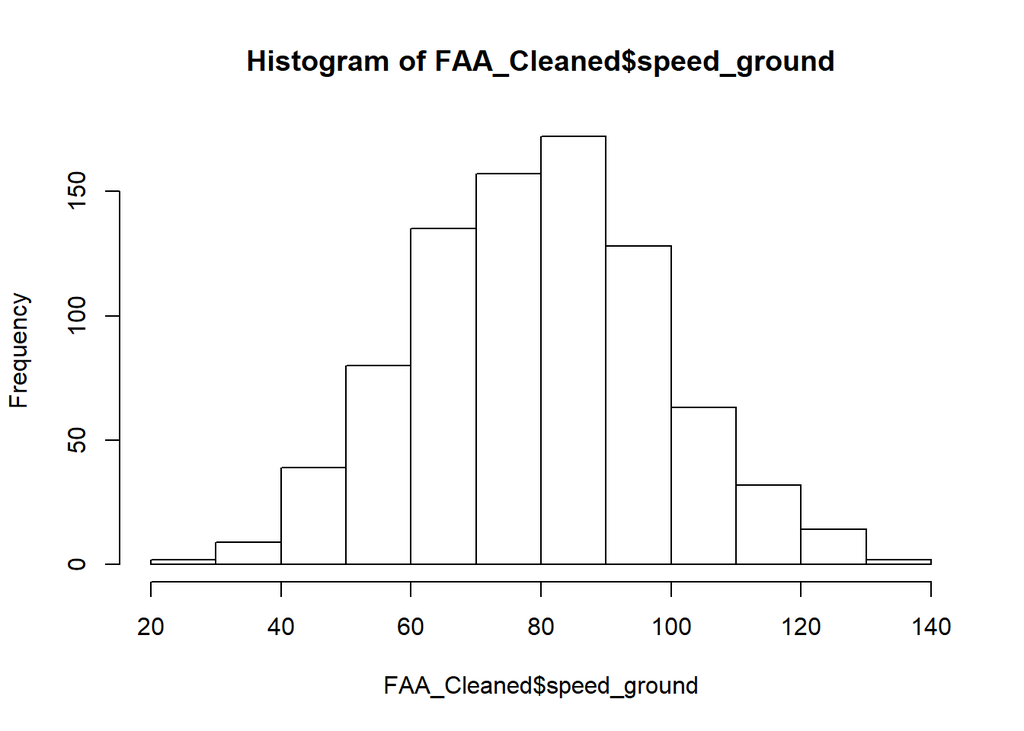

```r
hist(FAA_Cleaned$speed_ground)
```

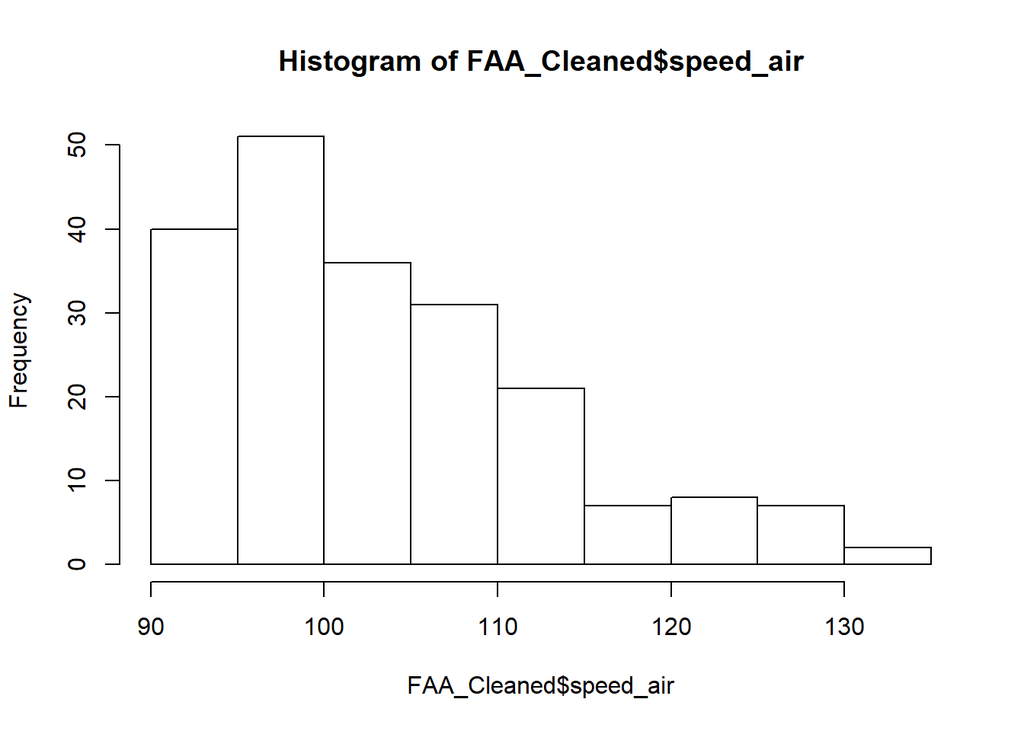

```r
hist(FAA_Cleaned$speed_air)
```

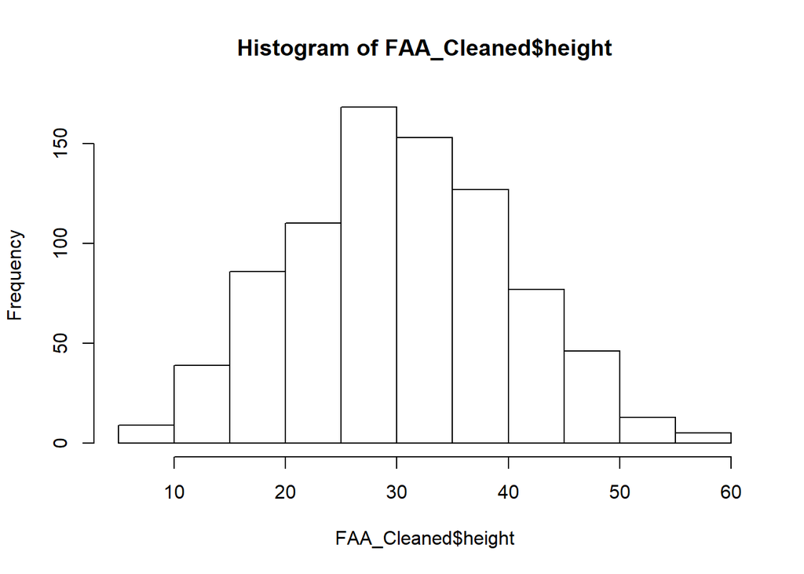

```r
hist(FAA_Cleaned$height)
```

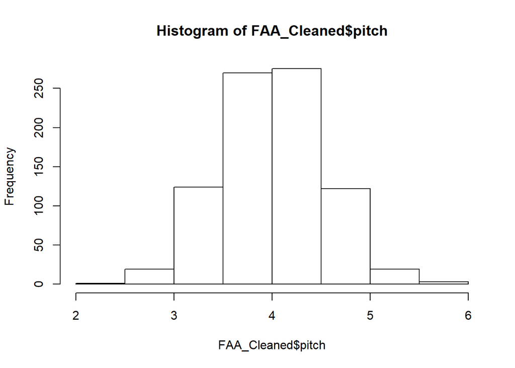

```r
hist(FAA_Cleaned$pitch)
```

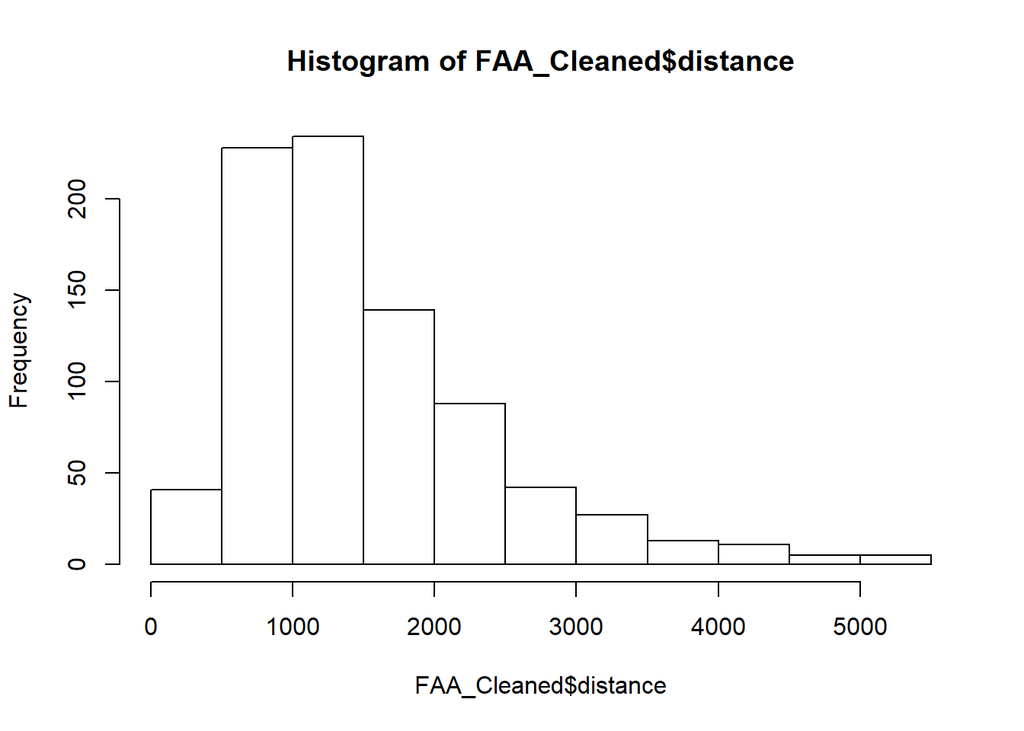

```r
hist(FAA_Cleaned$distance)
```

#plotting boxplot of all variables to check the outliers

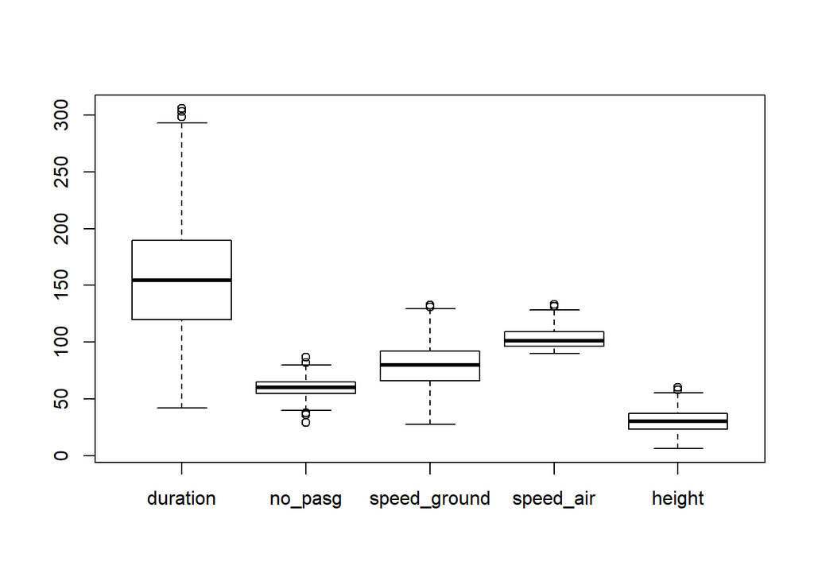

```r
boxplot(FAA_Cleaned[,2:6])
```

# Chapter 3: Correlation

```r
cor(FAA_Cleaned)
```

```
##                 aircraft duration      no_pasg speed_ground speed_air
## aircraft      1.00000000       NA -0.024856332 -0.046983526        NA
## duration              NA        1           NA           NA        NA
## no_pasg      -0.02485633       NA  1.000000000  0.005633391        NA
## speed_ground -0.04698353       NA  0.005633391  1.000000000        NA
## speed_air             NA       NA           NA           NA         1
## height       -0.01608764       NA  0.048143292 -0.052707632        NA
## pitch         0.35533110       NA -0.019323323 -0.043399151        NA
## distance      0.23685130       NA -0.017292859  0.860778831        NA
##                   height       pitch    distance
## aircraft     -0.01608764  0.35533110  0.23685130
## duration              NA          NA          NA
## no_pasg       0.04814329 -0.01932332 -0.01729286
## speed_ground -0.05270763 -0.04339915  0.86077883
## speed_air             NA          NA          NA
## height        1.00000000  0.02179522  0.09993783
## pitch         0.02179522  1.00000000  0.08633229
## distance      0.09993783  0.08633229  1.00000000
```

#check correlation of each variable with distance

```r
cor(FAA_Cleaned$distance,FAA_Cleaned[c(1:7)],use = "pairwise.complete.obs")
```

```
##       aircraft    duration     no_pasg speed_ground speed_air     height
## [1,] 0.2368513 -0.05202997 -0.01729286    0.8607788 0.9420971 0.09993783
##           pitch
## [1,] 0.08633229
```

#Creating a table that ranks the factors based on the size (absolute value) of the correlation. #Table 1

```r
Table1 <- setNames(data.frame(matrix(ncol = 3, nrow = 8)), c('Name_of_Variable', 'Size_Of_Correlation', 'Direction_Of_Correlation'))
Table1$Name_of_Variable <- colnames(FAA_Cleaned)
Table1$Size_Of_Correlation <- abs(cor(FAA_Cleaned$distance,FAA_Cleaned[,c(1:8)],use = "pairwise.complete.obs")[1,])
Table1$Direction_Of_Correlation <- sign(cor(FAA_Cleaned$distance,FAA_Cleaned[,c(1:8)],use = "pairwise.complete.obs")[1,])
Table1 <- Table1[order(Table1$Size_Of_Correlation,decreasing = T),]
print(Table1)
```

```
##   Name_of_Variable Size_Of_Correlation Direction_Of_Correlation
## 8         distance          1.00000000                        1
## 5        speed_air          0.94209714                        1
## 4     speed_ground          0.86077883                        1
## 1         aircraft          0.23685130                        1
## 6           height          0.09993783                        1
## 7            pitch          0.08633229                        1
## 2         duration          0.05202997                       -1
## 3          no_pasg          0.01729286                       -1
```

#pairwise correlation X-Y plots

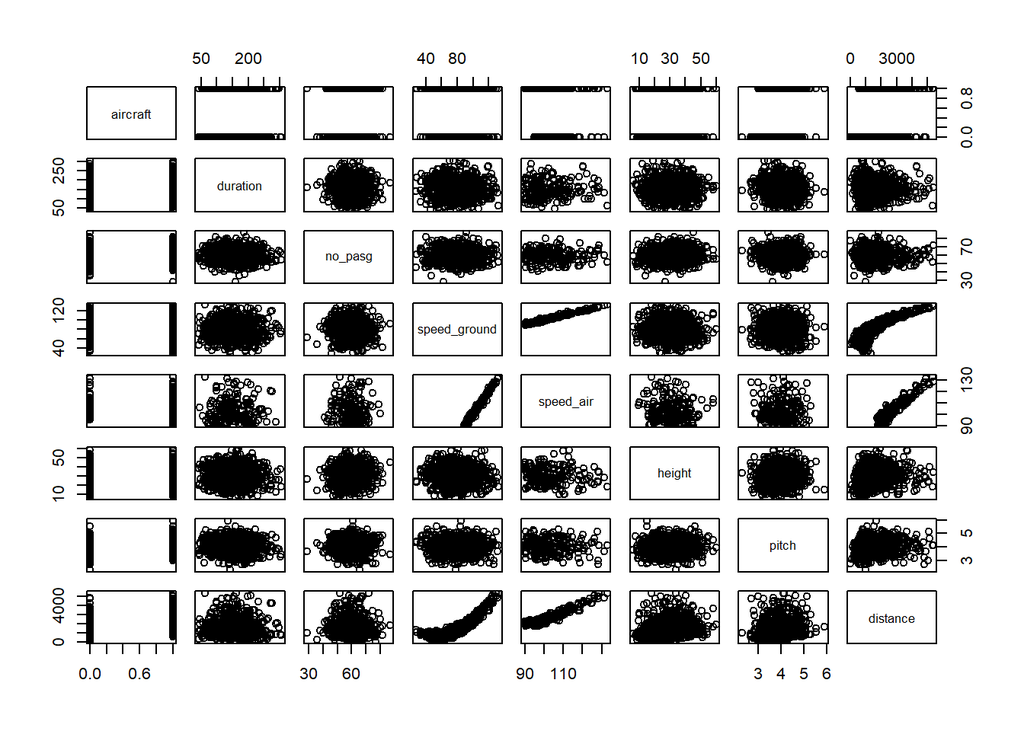

```r
pairs(FAA_Cleaned)
```

# Chapter 4: Regression using a single factor each time

We regress Y (landing distance) on each of the X variables. We provide a table that ranks the factors based on its significance.

```r
duration_lm <- tidy(lm(distance ~ duration,FAA_Cleaned))
speedair_lm <- tidy(lm(distance ~ speed_air,FAA_Cleaned))
speedground_lm <- tidy(lm(distance ~ speed_ground,FAA_Cleaned))
pitch_lm <- tidy(lm(distance ~ pitch,FAA_Cleaned))
height_lm <- tidy(lm(distance ~ height,FAA_Cleaned))
no_pasg_lm <- tidy(lm(distance ~ no_pasg,FAA_Cleaned))
```

# Creating a table that ranks the factors based on its significance.

#Table 2

```r
Table2 <- setNames(data.frame(matrix(ncol = 3, nrow = 7)), c('Name_of_Variable', 'Size_Of_PValue', 'Direction_Of_Regression_Coefficient'))
Table2$Name_of_Variable <- colnames(FAA_Cleaned[,1:7])
for (i in 1:7) {
  fit <- lm(FAA_Cleaned[,8]~FAA_Cleaned[,i])
  Table2$`Size_Of_PValue`[i] <- summary(fit)$coefficients[2,4]
  Table2$Direction_Of_Regression_Coefficient[i] <- sign(fit$coefficients[2])
}
Table2 <- Table2[order(Table2$`Size_Of_PValue`,decreasing = F),]
print(Table2)
```

```
##   Name_of_Variable Size_Of_PValue Direction_Of_Regression_Coefficient
## 4     speed_ground  5.951812e-246                                   1
## 5        speed_air   2.500461e-97                                   1
## 1         aircraft   4.377142e-12                                   1
## 6           height   3.885891e-03                                   1
## 7            pitch   1.268068e-02                                   1
## 2         duration   1.457886e-01                                  -1
## 3          no_pasg   6.182093e-01                                  -1
```

#Standardizing each X variable

```r
standardize <- function(x) {
  return((x - mean(x,na.rm = TRUE))/sd(x,na.rm = TRUE))
}
```

#Regressing Y based on this new standardized variable

```r
duration_lm_std <- tidy(lm(distance ~ standardize(duration),FAA_Cleaned))
speedair_lm_std <- tidy(lm(distance ~ standardize(speed_air),FAA_Cleaned))
speedground_lm_std <- tidy(lm(distance ~ standardize(speed_ground),FAA_Cleaned))
pitch_lm_std <- tidy(lm(distance ~ standardize(pitch),FAA_Cleaned))
height_lm_std <- tidy(lm(distance ~ standardize(height),FAA_Cleaned))
no_pasg_lm_std <- tidy(lm(distance ~ standardize(no_pasg),FAA_Cleaned))
```

#Creating a table that ranks the factors based on the size of the regression coefficient #Table 3

```r
Table3 <- setNames(data.frame(matrix(ncol = 3, nrow = 7)), c('Name_of_Variable', 'Size_Of_Regression_Coefficient', 'Dir_Of_Regression_Coefficient'))
Table3$Name_of_Variable <- colnames(FAA_Cleaned[,1:7])
for (i in 1:7) {
  fit <- lm(FAA_Cleaned[,8]~FAA_Cleaned[,i])
  Table3$Size_Of_Regression_Coefficient[i] <- abs(fit$coefficients[2])
  Table3$Dir_Of_Regression_Coefficient[i] <- sign(fit$coefficients[2])
}
Table3 <- Table3[order(Table3$Size_Of_Regression_Coefficient,decreasing = T),]
print(Table3)
```

```
##   Name_of_Variable Size_Of_Regression_Coefficient Dir_Of_Regression_Coefficient
## 1         aircraft                     424.834984                             1
## 7            pitch                     146.892401                             1
## 5        speed_air                      79.532095                             1
## 4     speed_ground                      40.825150                             1
## 6           height                       9.151432                             1
## 3          no_pasg                       2.065074                            -1
## 2         duration                       0.972696                            -1
```

#Creating a single table from table1, table2, table3 than ranks all the factors based on their relative importance in determining the landing distance. We call it Table 0. #Table 0

```r
Table0 <- setNames(data.frame(matrix(ncol = 2, nrow = 7)), c('Variable_Rank', 'Name_of_Variable'))
Table0$Variable_Rank <- c(1:7)
Table0$Name_of_Variable <- Table2$Name_of_Variable
Table0
```

```
##   Variable_Rank Name_of_Variable
## 1             1     speed_ground
## 2             2        speed_air
## 3             3         aircraft
## 4             4           height
## 5             5            pitch
## 6             6         duration
## 7             7          no_pasg
```

# Chapter 5: Collinearity check

#Developing regression model of landing distance with speed_ground and speed_air and finally regressing landing distance with both of them together.

#Landing distance with Speed on Ground

```r
(fit1 <- tidy(lm(distance ~ speed_ground,FAA_Cleaned)))
```

```
## # A tibble: 2 x 5
##   term         estimate std.error statistic   p.value
##   <chr>           <dbl>     <dbl>     <dbl>     <dbl>
## 1 (Intercept)   -1721.     68.4       -25.2 2.32e-104
## 2 speed_ground     40.8     0.837      48.8 5.95e-246
```

#Landing distance with Speed in Air

```r
(fit2 <- tidy(lm(distance ~ speed_air,FAA_Cleaned)))
```

```
## # A tibble: 2 x 5
##   term        estimate std.error statistic  p.value
##   <chr>          <dbl>     <dbl>     <dbl>    <dbl>
## 1 (Intercept)  -5456.     208.       -26.3 5.82e-67
## 2 speed_air       79.5      2.00      39.8 2.50e-97
```

```r
summary(fit2)
```

```
##      term              estimate          std.error         statistic
##  Length:2           Min.   :-5455.71   Min.   :  1.997   Min.   :-26.287
##  Class :character   1st Qu.:-4071.90   1st Qu.: 53.384   1st Qu.: -9.758
##  Mode  :character   Median :-2688.09   Median :104.772   Median :  6.772
##                     Mean   :-2688.09   Mean   :104.772   Mean   :  6.772
##                     3rd Qu.:-1304.28   3rd Qu.:156.159   3rd Qu.: 23.301
##                     Max.   :   79.53   Max.   :207.547   Max.   : 39.830
##     p.value
##  Min.   :0.000e+00
##  1st Qu.:1.454e-67
##  Median :2.909e-67
##  Mean   :2.909e-67
##  3rd Qu.:4.363e-67
##  Max.   :5.818e-67
```

#Landing distance with Speed on Ground and Speed in Air

```r
(fit3 <- tidy(lm(distance ~ speed_air + speed_ground,FAA_Cleaned)))
```

```
## # A tibble: 3 x 5
##   term         estimate std.error statistic  p.value
##   <chr>           <dbl>     <dbl>     <dbl>    <dbl>
## 1 (Intercept)   -5462.      207.     -26.3  6.59e-67
## 2 speed_air        94.0      12.9      7.29 6.99e-12
## 3 speed_ground    -14.4      12.7     -1.13 2.58e- 1
```

Comparing the three regression coefficients, we see that while used individually the slope coefficient for speed_air is higher as compared to slope coefficient for speed_ground.

However on including both variables as predictors, we observe that it is now negatively correlated with distance.

```r
cor(FAA_Cleaned$speed_air,FAA_Cleaned$speed_ground,use = "pairwise.complete.obs")
```

```
## [1] 0.9879383
```

As variables ‘speed_ground’ and ‘speed_air’ have high correlation of 0.988, we will keep one of them in the model selection. We will pick ‘speed_ground’ over ‘speed_air’ as later has approximately 75% NA values while ‘speed_ground’ has none.

# Chapter 6: Variable Selection

#Variable selection based on Table 0 created above.

```r
fit1 <- lm(FAA_Cleaned$distance~FAA_Cleaned$speed_ground)
fit2 <- lm(FAA_Cleaned$distance~FAA_Cleaned$speed_ground+FAA_Cleaned$aircraft)
fit3 <- lm(FAA_Cleaned$distance~FAA_Cleaned$speed_ground+FAA_Cleaned$aircraft+FAA_Cleaned$height)
fit4 <- lm(FAA_Cleaned$distance~FAA_Cleaned$speed_ground+FAA_Cleaned$aircraft+FAA_Cleaned$height+FAA_Cleaned$pitch)
fit5 <- lm(FAA_Cleaned$distance~FAA_Cleaned$speed_ground+FAA_Cleaned$aircraft+FAA_Cleaned$height+FAA_Cleaned$pitch+FAA_Cleaned$duration)
fit6 <- lm(FAA_Cleaned$distance~FAA_Cleaned$speed_ground+FAA_Cleaned$aircraft+FAA_Cleaned$height+FAA_Cleaned$pitch+FAA_Cleaned$duration+FAA_Cleaned$no_pasg)
```

#Calculating R-square for each model and plotting these R-squared values against the number of variables.

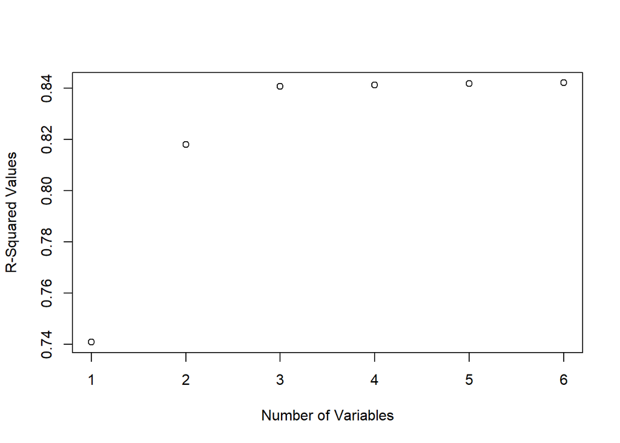

```r
plot(x=c(1,2,3,4,5,6),y=(c(summary(fit1)$r.squared,summary(fit2)$r.squared,summary(fit3)$r.squared,summary(fit4)$r.squared,summary(fit5)$r.squared,summary(fit6)$r.squared)),xlab = "Number of Variables",ylab = "R-Squared Values")
```

We observe that the R-squared value increases with increase in number of variables.

However, the increase in R-square isn’t significant after adding more than 3 variables.

We now plot the same models using the Adjusted R-squared to check if we should add more variables or 3 variables can be enough.

#Calculating Adjusted R-square for each model and plotting these R-squared values against the number of variables.

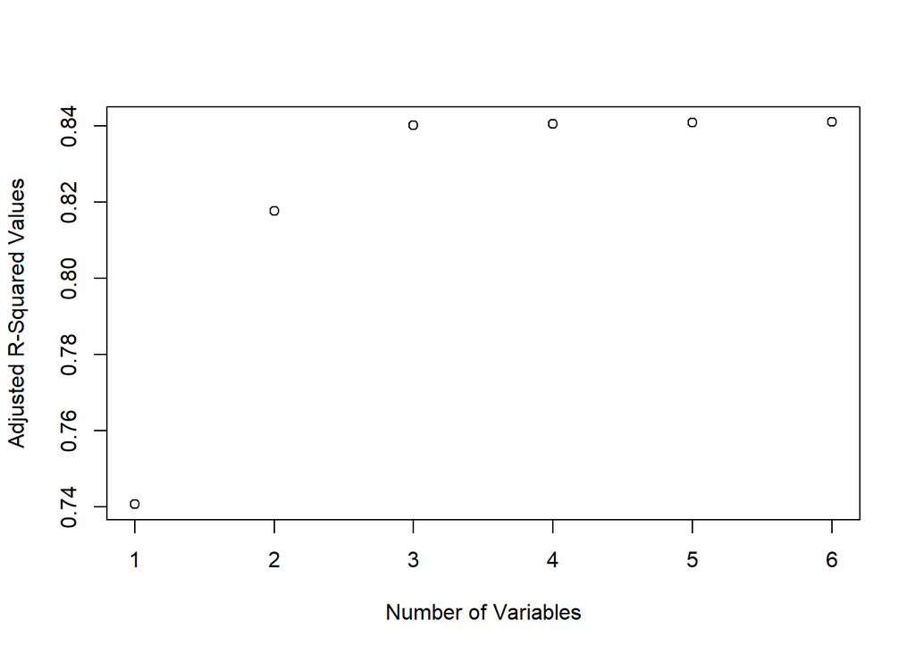

```r
plot(x=c(1,2,3,4,5,6),y=(c(summary(fit1)$adj.r.squared,summary(fit2)$adj.r.squared,summary(fit3)$adj.r.squared,summary(fit4)$adj.r.squared,summary(fit5)$adj.r.squared,summary(fit6)$adj.r.squared)),xlab = "Number of Variables",ylab = "Adjusted R-Squared Values")
```

We again note that the increase in R-square isn’t much after 3 predictor variables.

#Calculating AIC values for each model and plotting these values against the number of variables.

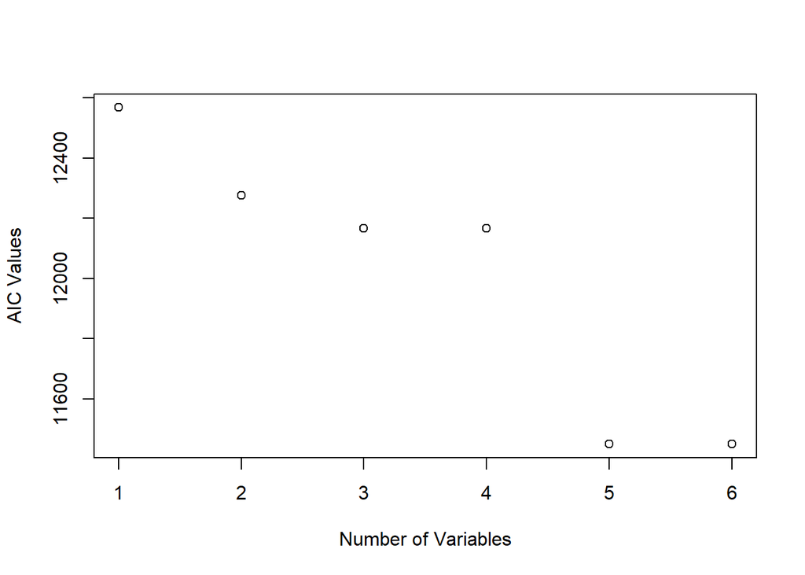

```r
plot(x=c(1,2,3,4,5,6),y=(c(AIC(fit1),AIC(fit2),AIC(fit3),AIC(fit4),AIC(fit5),AIC(fit6))),xlab = "Number of Variables",ylab = "AIC Values")
```

From past 3 plots, we can conclude that a good model can be built using 5 of the 6 variables from the data to determine the landing distance.

Thus, we will use ‘speed_ground’,‘aircraft’,‘height’,‘pitch’ and ‘duration’ variables to determine the Landing Distance in our Model.